# MegaSearch

## Group Assignment week 8

Max Petra - 11028335

Menno Lont - 11061200

Michael Faber - 6087582

# Query result page

- **Multi_match** over titel, tekst, plaatsen ed.
  - Gewogen Velden
    - bvb: als query in titel voorkomt telt het zwaarder mee dan in de tekst.
  - **Most_fields** type voor een gecombineerde score.
- **Highlights** zijn stukjes uit de tekst waarin woorden van de zoekterm veel voorkomen.

# Query result page

```python
serp(qry='articles about Gasoline Sales in United States')
```

```
10 best hits in: 39 ms.


JAPAN FIRMS TO LAUNCH SALES OF 100 OCTANE GASOLINE

Formula Shell has achieved strong <em>sales</em> <em>in</em> Japan despite a
higher price than regular octane <em>gasoline</em>,...


MORE RAIN IN THE NORTHEASTERN UNITED STATES

A flood warning remains <em>in</em> effect for small rivers <em>in</em>
southern New Hampshire and extreme southwestern...


SMALL RISE SEEN IN U.S. GASOLINE INVENTORIES

U.S. stocks of <em>gasoline</em> for the week ended
May 29, oil traders and analysts said....


UNITED STATES LINES LAYS OFF FAR EAST STAFF

<em>United</em> <em>States</em> Lines Inc> has laid
off 260 employees, almost its entire Far East staff, its Hong
Kong...


EC BACKS NEW MOVE TO ENCOURAGE UNLEADED GASOLINE

The EC Executive Commission has backed
a plan to allow member countries to ban regular leaded <em>gasoline</em>...


U.S. GASOLINE SURPLUS SEEN OVER NEAR TERM

"They key question is how much <em>gasoline</em> refiners produce <em>in</em>
the coming weeks," said Larry Goldstein of...


```

[output cut: 11 more lines]

```
refiners can...


MORE BRITISH GOLD ARTICLES HALLMARKED

The number of British gold <em>articles</em>
hallmarked during the first quarter of this year rose by more
than...


U.S. DEFENDS STOCKPILED TIN SALES IN 1986

The <em>United</em> <em>States</em> defended its <em>sales</em>
of stockpiled tin <em>in</em> 1986 <em>in</em> reaction to criticism from
Malaysian...
```

# Wordcloud

- Laat de 25 meest voorkomende woorden overzichtelijk zien
- De woorden komen uit de tekst van de eerste tien resultaten van de query

# Wordcloud

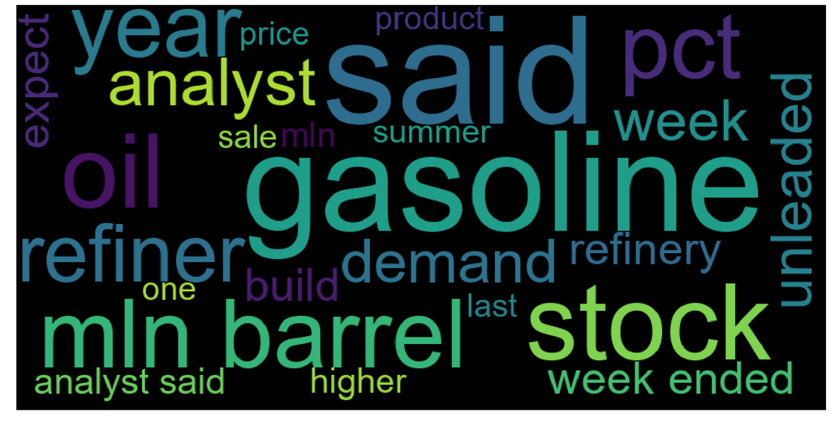

```python
wc(qry='Gasoline Sales')
```

# Timeline

- De eerste tien resultaten gesorteerd op datum
  - De titels zijn te lang
  - De eerste twee woorden als indicator

# Timeline

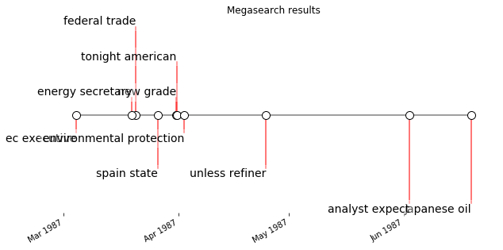

```python
tlshow(qry='Gasoline Sales')
```

# Faceted Search

```python
serp(plc=['Japan', 'USA'])
```

```
10 best hits in: 13 ms.


JAPANESE ECONOMIST SEES STABLE YEN/DOLLAR RATES

['japan', 'usa']


JAPAN LIKELY TO LET U.S. BANKS DEAL SECURITIES

['japan', 'usa']


JAPAN, U.S. SET TO BEGIN HIGH-LEVEL TRADE TALKS

['japan', 'usa']


ECONOMIC SPOTLIGHT - EUROYEN BOND ISSUES INCREASE

['japan', 'usa']


JAPANESE MINISTRY DENIES EXPORT QUOTA FOR DAIHATSU

['japan', 'usa']


U.S. TELLS JAPAN TO DO MORE TO CUT TRADE SURPLUS

['japan', 'usa']


BALDRIGE SAYS U.S. MAY RETALIATE ON KANSAI

['usa', 'japan']


YEUTTER SAYS BUDGET CUT KEY TO BETTER U.S. TRADE

['usa', 'japan']


FEDERAL EXPRESS TENTATIVELY GETS US/TOKYO ROUTE

['usa', 'japan']


FOREIGN BROKERS MAY GET MORE ACCESS TO JAPAN BONDS

['usa', 'japan']
```

# Geplande functionaliteit

[figure not shown]

- Maat van node representeert rank/'goodness'
- Afstand\hoeveelheid verbindingen tussen nodes representeert similarity
- Soortgelijke resultaten samen gegroepeerd; klopt het resultaat compleet niet kan de gebruiker meteen verder naar een andere cluster
- Geen scheiding in rank; hebben twee resultaten een soortgelijke 'goodness', dan zijn de nodes ongeveer even groot
- Mooi!
- Makkelijk te implementeren in Python (networkx), moeilijk te implementeren in HTML (links, clickboxes)

## Bedankt voor jullie aandacht.